# Writing Functions in R

Amit Agni

17/02/2019

## Chapter 1 : A quick refresher

- Every function has 3 parts : formals, body and environment
- Last evaulated expression will be returned by the function
- return(value) should be used as special case and not routinely as it forces the function to stop execution and return the value
- Functions are objects, hence mean2 <- mean

```r
add <- function(x,y=1) { x + y}
formals(add)
```

```
## $x
##
##
## $y
## [1] 1
```

```r
body(add)
```

```
## {
##     x + y
## }
```

```r
environment(add)
```

```
## <environment: R_GlobalEnv>
```

**Scoping and environments**

- R looks for the variable in the environment 1 level up

**Data Structures**  
* NULL often used to indicate the absence of a vector  
* NA used to indicate absence of value in a vector

```r
typeof(NULL)
```

```
## [1] "NULL"
```

```r
length(NULL)
```

```
## [1] 0
```

```r
typeof(NA)
```

```
## [1] "logical"
```

```r
length(NA)
```

```
## [1] 1
```

**Lists**  
* Lists created using ()  
* [ extracts a sublist  
* [[ and $ extracts elements, remove a level of hierarchy

```r
tricky_list <- lm(formula = mpg ~ wt, data = mtcars,
                  x = TRUE, y = TRUE)

tricky_list<- str(model)


typeof(str(model))

# Guess where the regression model is stored
names(tricky_list)

# Use names() and str() on the model element
names(tricky_list[["model"]])
str(tricky_list[["model"]])

# Subset the coefficients element
tricky_list[["model"]][["coefficients"]]

# Subset the wt element
tricky_list[["model"]][["coefficients"]][["wt"]]
```

**For Loops**

- A data frame is build on top a list, with the columns being the sublists

```r
set.seed(1)
df <- data.frame(
    a = rnorm(10),
    b = rnorm(10),
    c = rnorm(10),
    d = rnorm(10)
)
#DF as a list of lists
df[[1]]
```

```
##  [1] -0.6264538  0.1836433 -0.8356286  1.5952808  0.3295078 -0.8204684
##  [7]  0.4874291  0.7383247  0.5757814 -0.3053884
```

> A better method is to use the seq_along() function. This function generates a sequence along the index of the object passed to it, but handles the empty case much better.
- without seq_along we get error  
  Error in .subset2(x, i, exact = exact) : subscript out of bounds

```r
for (i in 1:ncol(df)) {
  print(median(df[[i]]))
}
```

```
## [1] 0.2565755
## [1] 0.4918723
## [1] 0.009218122
## [1] -0.05655922
```

```r
for (i in seq_along(df)) {
  print(median(df[[i]]))
}
```

```
## [1] 0.2565755
## [1] 0.4918723
## [1] 0.009218122
## [1] -0.05655922
```

```r
empty_df <- data.frame()
#for (i in 1:ncol(empty_df)) {
#  print(median(empty_df[[i]]))
#}

for (i in seq_along(empty_df)) {
  print(median(empty_df[[i]]))
}
```

**Saving loop output**

> Before you start the loop, you must always allocate sufficient space for the output, let’s say an object called output. This is very important for efficiency: if you grow the for loop at each iteration (e.g. using c()), your for loop will be very slow.

> A general way of creating an empty vector of given length is the vector() function. It has two arguments: the type of the vector (“logical”, “integer”, “double”, “character”, etc.) and the length of the vector.

> Then, at each iteration of the loop you must store the output in the corresponding entry of the output vector, i.e. assign the result to output[[i]]. (You might ask why we are using double brackets here when output is a vector. It’s primarily for generalizability: this subsetting will work whether output is a vector or a list.)

```r
# Create new double vector: output
output <- vector(mode = "double",length = ncol(df))

# Alter the loop
for (i in seq_along(df)) {
  # Change code to store result in output
  output[[i]] <- median(df[[i]])
}

# Print output
output
```

```
## [1]  0.256575548  0.491872279  0.009218122 -0.056559219
```

## Chapter 2 : R Functions

- use warning()
- use message()

## Chapter 3 : Why functional programming

- Passing functions as arguments
- eg lapply or sapply

**map functions**

- map() returns a list
- map_dbl() returns a double vector
- map_lgl()
- map_int()
- map_chr()
- map(.x, .f, …)
  - If .x is map applies the function to each element of the vector
  - If .x is a df, map iterates over columns of the DF and returns a list
  - If .x is a list, map iterates over elements of the list and returns a list

**Advantages of map functions in purrr**

- Handy shortcuts
- more consistent than lapply()
- takes much less time to solve iteration problems

> The map functions are what we call type consistent. This means you know exactly what type of output to expect regardless of the input. map_lgl() either returns either a logical vector or an error. map_dbl() returns either a double or an error. One way to check the output type is to run the corresponding function on the first element. For example, mean(df[[1]]) returns a single numeric value, suggesting map_dbl().

```r
p_load(purrr)

p_load(nycflights13)
# Find the mean of each column
map_dbl(planes, mean)
```

```
##      tailnum         year         type manufacturer        model
##           NA           NA           NA           NA           NA
##      engines        seats        speed       engine
##     1.995184   154.316376           NA           NA
```

```r
# Find the mean of each column, excluding missing values
map_dbl(planes, mean, na.rm = TRUE)
```

```
##      tailnum         year         type manufacturer        model
##           NA  2000.484010           NA           NA           NA
##      engines        seats        speed       engine
##     1.995184   154.316376   236.782609           NA
```

```r
# Find the 5th percentile of each column, excluding missing values
#map_dbl(planes, quantile, probs = c(0.05),na.rm = TRUE)


# Find the columns that are numeric
map_lgl(planes, is.numeric)
```

```
##      tailnum         year         type manufacturer        model
##        FALSE         TRUE        FALSE        FALSE        FALSE
##      engines        seats        speed       engine
##         TRUE         TRUE         TRUE        FALSE
```

```r
# Find the type of each column
map_chr(planes, typeof)
```

```
##      tailnum         year         type manufacturer        model
##  "character"    "integer"  "character"  "character"  "character"
##      engines        seats        speed       engine
##    "integer"    "integer"    "integer"  "character"
```

```r
# Find a summary of each column
map(planes, summary)
```

```
## $tailnum
##    Length     Class      Mode
##      3322 character character
##
## $year
##    Min. 1st Qu.  Median    Mean 3rd Qu.    Max.    NA's
##    1956    1997    2001    2000    2005    2013      70
##
## $type
##    Length     Class      Mode
##      3322 character character
##
## $manufacturer
##    Length     Class      Mode
##      3322 character character
##
## $model
##    Length     Class      Mode
##      3322 character character
##
## $engines
##    Min. 1st Qu.  Median    Mean 3rd Qu.    Max.
##   1.000   2.000   2.000   1.995   2.000   4.000
##
## $seats
##    Min. 1st Qu.  Median    Mean 3rd Qu.    Max.
##     2.0   140.0   149.0   154.3   182.0   450.0
##
## $speed
##    Min. 1st Qu.  Median    Mean 3rd Qu.    Max.    NA's
##    90.0   107.5   162.0   236.8   432.0   432.0    3299
##
## $engine
##    Length     Class      Mode
##      3322 character character
```

**Shortcuts for specifying .f**

- ~ and . can be used for specifying anonymous functions

```r
map_dbl(df, function(x) sum(is.na(x)))
```

```
## a b c d
## 0 0 0 0
```

```r
map_dbl(df, ~sum(is.na(.)))
```

```
## a b c d
## 0 0 0 0
```

- create 3 lists and run lm on each

```r
cyl <- split(mtcars,mtcars$cyl)
map(cyl, ~ lm(mpg ~ wt, data = .))
```

```
## $`4`
##
## Call:
## lm(formula = mpg ~ wt, data = .)
##
## Coefficients:
## (Intercept)           wt
##      39.571       -5.647
##
##
## $`6`
##
## Call:
## lm(formula = mpg ~ wt, data = .)
##
## Coefficients:
## (Intercept)           wt
##       28.41        -2.78
##
##
## $`8`
##
## Call:
## lm(formula = mpg ~ wt, data = .)
##
## Coefficients:
## (Intercept)           wt
##      23.868       -2.192
```

```r
# Save the result from the previous exercise to the variable models
models <- map(cyl, ~ lm(mpg ~ wt, data = .))

# Use map and coef to get the coefficients for each model: coefs
coefs <- map(models, coef)

# Use string shortcut to extract the wt coefficient
map(coefs, "wt")
```

```
## $`4`
## [1] -5.647025
##
## $`6`
## [1] -2.780106
##
## $`8`
## [1] -2.192438
```

## Chapter 4 : Advanced inputs and outputs

**Error handling**

- safely() - The function that is returned is modified so it never throws an error (and never stops the rest of your computation!)
- possibly()
- quietly()

> purrr provides a function transpose() that reshapes a list so the inner-most level becomes the outer-most level. In otherwords, it turns a list-of-lists “inside-out”. Consider the following list:

nested_list <- list( x1 = list(a = 1, b = 2), x2 = list(a = 3, b = 4))

> If I need to extract the a element in x1, I could do nested_list[[“x1”]][[“a”]]. However, if I transpose the list first, the order of subsetting reverses. That is, to extract the same element I could also do transpose(nested_list)[[“a”]][[“x1”]].

```r
urls <- list()
urls[["example"]] <- "http://example.org"
urls[["rproj"]] <- "http://www.r-project.org"
urls[["asdf"]] <- "http://asdfasdasdkfjlda"

urls
```

```
## $example
## [1] "http://example.org"
##
## $rproj
## [1] "http://www.r-project.org"
##
## $asdf
## [1] "http://asdfasdasdkfjlda"
```

```r
# Define safe_readLines() and html
safe_readLines <- safely(readLines)
html <- map(urls, safe_readLines)
# Examine the structure of transpose(html)
str(transpose(html))
```

```
## List of 2
##  $ result:List of 3
##   ..$ example: chr [1:50] "<!doctype html>" "<html>" "<head>" "    <title>Example Domain</title>" ...
##   ..$ rproj  : chr [1:122] "<!DOCTYPE html>" "<html lang=\"en\">" "  <head>" "    <meta charset=\"utf-8\">" ...
##   ..$ asdf   : NULL
##  $ error :List of 3
##   ..$ example: NULL
##   ..$ rproj  : NULL
##   ..$ asdf   :List of 2
##   .. ..$ message: chr "cannot open the connection to 'http://asdfasdasdkfjlda'"
##   .. ..$ call   : language file(con, "r")
##   .. ..- attr(*, "class")= chr [1:3] "simpleError" "error" "condition"
```

```r
# Extract the results: res
res <- transpose(html)[["result"]]

# Extract the errors: errs
errs <- transpose(html)[["error"]]
```

**maps over multiple arguments**

- map2 allows to add second argument map2(.x,.y, .f , ..)
- pmap() - multiple arguments
- invoke_map() - iterate over functions and arguments

**map2**

```r
# Initialize n
n <- list(5, 10, 20)

# Create a list mu containing the values: 1, 5, and 10
mu <- list(1, 5, 10)

# Edit to call map2() on n and mu with rnorm() to simulate three samples
map2(n, mu, rnorm)
```

```
## [[1]]
## [1] 0.8354764 0.7466383 1.6969634 1.5566632 0.3112443
##
## [[2]]
##  [1] 4.292505 5.364582 5.768533 4.887654 5.881108 5.398106 4.387974
##  [8] 5.341120 3.870637 6.433024
##
## [[3]]
##  [1] 11.980400  9.632779  8.955865 10.569720  9.864945 12.401618  9.960760
##  [8] 10.689739 10.028002  9.256727 10.188792  8.195041 11.465555 10.153253
## [15] 12.172612 10.475510  9.290054 10.610726  9.065902  8.746367
```

**pmap**

```r
# Initialize n and mean and sd
n <- list(5, 10, 20)
mu <- list(1, 5, 10)
sd <- list(0.1, 1, 0.1)

# Edit this call to pmap() to iterate over the sd list as well
pmap(list(mean = mu, n = n, sd = sd), rnorm)
```

```
## [[1]]
## [1] 1.0291446 0.9556708 1.0001105 1.0074341 0.9410479
##
## [[2]]
##  [1] 4.431331 4.864821 6.178087 3.476433 5.593946 5.332950 6.063100
##  [8] 4.695816 5.370019 5.267099
##
## [[3]]
##  [1]  9.945748 10.120787 10.116040 10.070021 10.158683 10.055849  9.872341
##  [8]  9.942673  9.877539  9.952660  9.937963 10.004212  9.908908 10.015803
## [15]  9.934542 10.176729 10.071671 10.091017 10.038419 10.168218
```

**invoke_map** >Sometimes it’s not the arguments to a function you want to iterate over, but a set of functions themselves. Imagine that instead of varying the parameters to rnorm() we want to simulate from different distributions, say, using rnorm(), runif(), and rexp(). How do we iterate over calling these functions?

Let’s use this approach to simulate three samples from the following three distributions: Normal(10, 1), Uniform(0, 5), and Exponential(5).

```r
# Define list of functions
funs <- list("rnorm", "runif", "rexp")

# Parameter list for rnorm()
rnorm_params <- list(mean = 10)

# Add a min element with value 0 and max element with value 5
runif_params <- list(min = 0, max = 5)

# Add a rate element with value 5
rexp_params <- list(rate = 5)

# Define params for each function
params <- list(
  rnorm_params,
  runif_params,
  rexp_params
)

# Call invoke_map() on funs supplying params and setting n to 5
invoke_map(funs, params, n = 5)
```

```
## [[1]]
## [1]  9.364264  9.538355 11.432282  9.349304  9.792619
##
## [[2]]
## [1] 1.7361534 0.6572116 1.8724343 3.1571011 1.9503947
##
## [[3]]
## [1] 0.07585114 0.07576536 0.02196025 0.18111149 0.03134158
```

**Maps with side effects**

*walk() function  
>walk() operates just like map() except it’s designed for functions that don’t return anything. You use walk() for functions with side effects like printing, plotting or saving.

```r
x<- list(1,"as",4)
map(x,print)
```

```
## [1] 1
## [1] "as"
## [1] 4
```

```
## [[1]]
## [1] 1
##
## [[2]]
## [1] "as"
##
## [[3]]
## [1] 4
```

```r
walk(x,print)
```

```
## [1] 1
## [1] "as"
## [1] 4
```

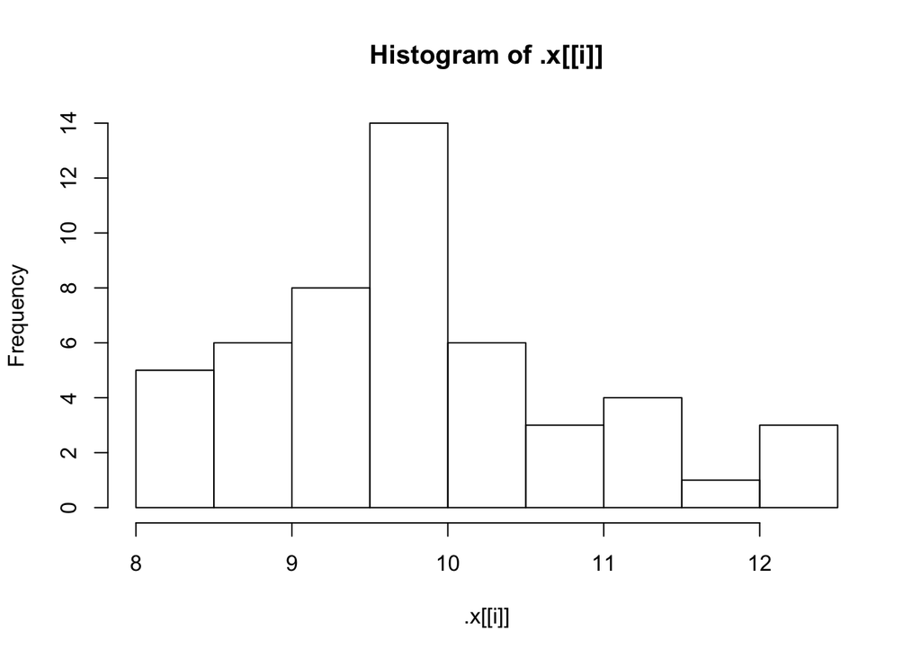

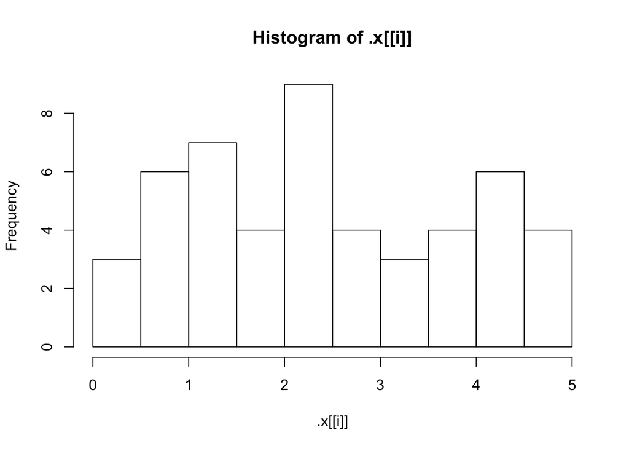

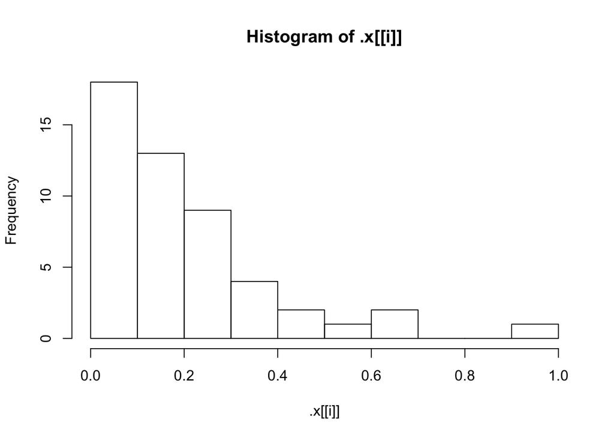

```r
# Define list of functions
funs <- list(Normal = "rnorm", Uniform = "runif", Exp = "rexp")

# Define params
params <- list(
  Normal = list(mean = 10),
  Uniform = list(min = 0, max = 5),
  Exp = list(rate = 5)
)

# Assign the simulated samples to sims
sims <- invoke_map(funs, params, n = 50)

# Use walk() to make a histogram of each element in sims
walk(sims, hist)
```

**Walking over two or more arguments**

> Those histograms were pretty good, but they really needed better breaks for the bins on the x-axis. That means we need to vary two arguments to hist(): x and breaks. Remember map2()? That allowed us to iterate over two arguments. Guess what? There is a walk2(), too!

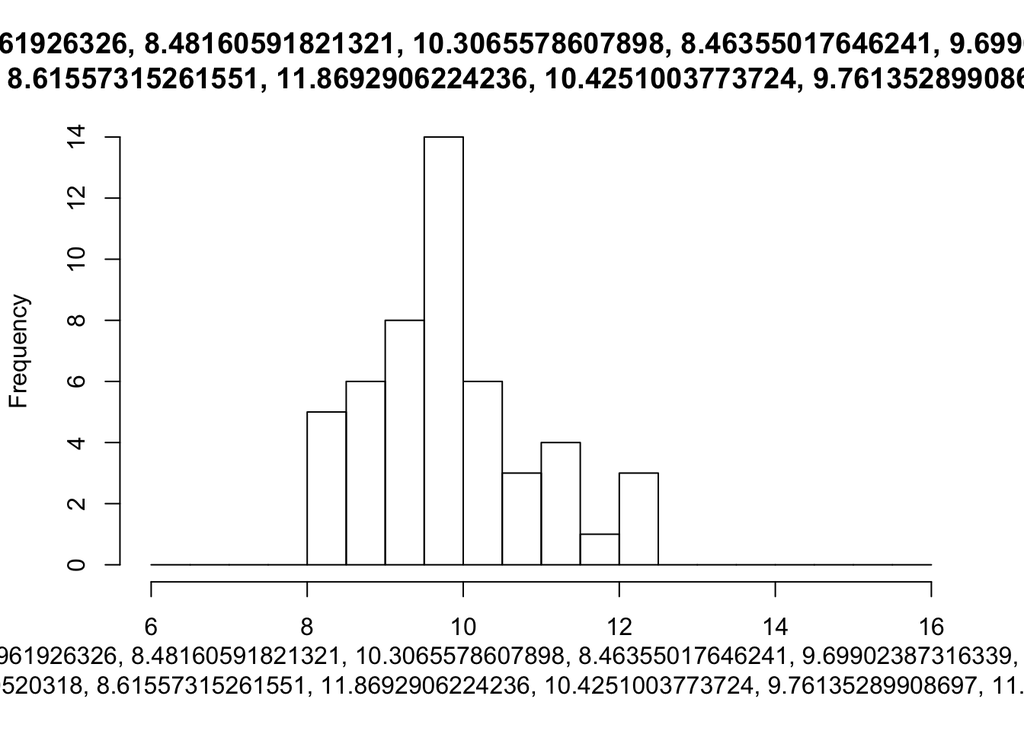

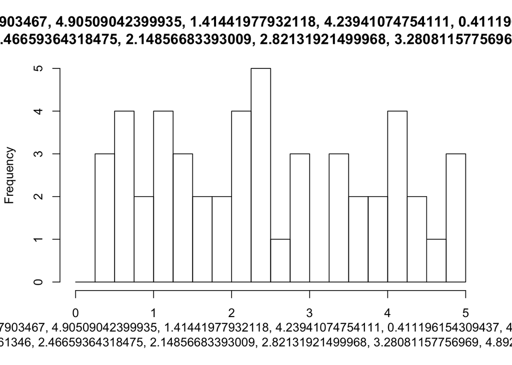

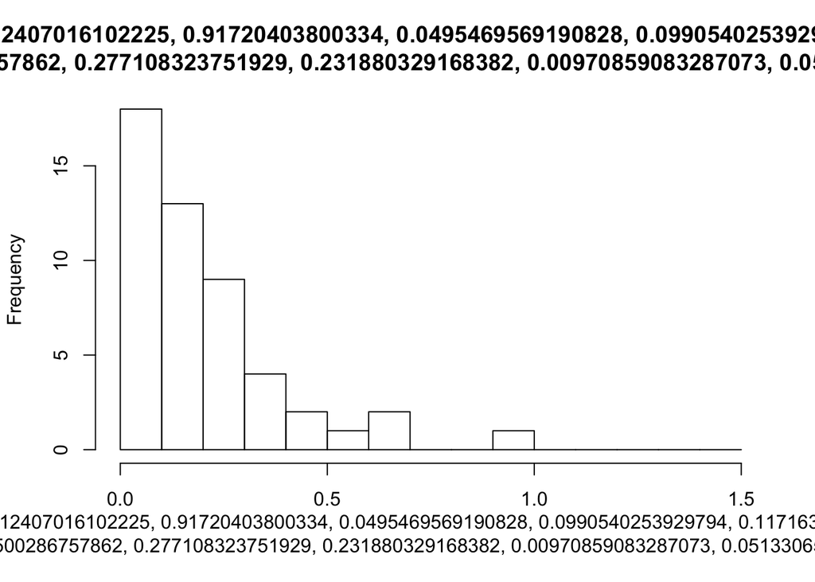

```r
# Replace "Sturges" with reasonable breaks for each sample
breaks_list <- list(
  Normal = seq(6, 16, 0.5),
  Uniform = seq(0, 5, 0.25),
  Exp = seq(0, 1.5, 0.1)
)

# Use walk2() to make histograms with the right breaks
walk2(sims, breaks_list, hist)
```

## Chapter 5 : Robust functions

**3 main problems** * Type-unstable functions : that sometimes return a list , sometimes a matrix, sometimes a vector  
* Non-standard evaluation  
* Hidden arguments eg stringasfactors

**Throwing errors**

- stopifnot() : Error messages not user friendly
- stop() : can be used for helpful messages

**Unstable types** * Common type-inconsistent functions are [, and sapply  
* all purrr functions are type consistent

**Global options** * getOption()  
* options(digits = 5) * ?options

# Summary

Most of the course is run by Hadley Wickham’s sister. The initial introduction in each chapter is given Hadley. Its a basic course and can be completed quickly if you are already using R. It gives a good introduction to the purrr::map functions.  
Some content that I liked in this course is summarised below :

- Lists :
  - [ extracts a sublist
  - [[ and $ extracts elements, remove a level of hierarchy
- R looks for the variable in the environment 1 level up
- A data frame is build on top a list, with the columns being the sublists
- A general way of creating an empty vector of given length is the vector() function.
  - It has two arguments: the type of the vector (“logical”, “integer”, “double”, “character”, etc.) and the length of the vector.
  - eg vector(mode = “double”,length = ncol(df))
- Saving loop output.
  - Always allocate sufficient space for the output, let’s say an object called output. This is very important for efficiency
  - if you grow the for loop at each iteration (e.g. using c()), your for loop will be very slow.
  - **eg : output <- vector(mode=“double”) and then in a loop output[[i]] <- median(df[[i]])**
- Use the base functions warning() and message() for error handling inside a function
- **map(mtcars,summary)** will apply the summary function to each column
- ~ and . can be used as shortcut for specifying anonymous functions
  - map_dbl(df, function(x) sum(is.na(x))) is same as **map_dbl(df, ~sum(is.na(.)))**
  - create 3 lists and run lm on each
    - cyl <- split(mtcars,mtcars$cyl)  
      **map(cyl, ~ lm(mpg ~ wt, data = .))**
- models <- map(cyl, ~ lm(mpg ~ wt, data = .))
  - Use map and coef to get the coefficients for each model : **coefs <- map(models, coef)**
  - Use string shortcut to extract the wt coefficient **map(coefs, “wt”)**
  - use map_dbl with the numeric shortcut to pull out the second element **map_dbl(coefs, 2)**
- safely(), possibly(), quietly()
- Multiple arguments
  - map2 allows to add second argument map2(.x,.y, .f , ..)
  - pmap() - multiple arguments
  - invoke_map() - iterate over functions and arguments
- Maps with side effects
  - walk() operates just like map() except it’s designed for functions that don’t return anything. You use walk() for functions with side effects like printing, plotting or saving.
  - walk2() and pwalk() for 2 or more arguments
- stopifnot() and stop() for error messages